# Modern concepts and methods in Macroecology and Biogeography

Day 5: Environmental drivers of neotropical palm diversity

Patrick Weigelt, Pierre Denelle & Holger Kreft

May 15th, 2024

*back to overview*

**Preparation:** Open your RStudio project and download new data for today from [Stud-IP](https://studip.uni-goettingen.de/dispatch.php/course/files/index/74501b33f332a6d238443bfbd502cc6c?cid=1746ae3fe971afbf90b74e3d64389586) (log in first) and unzip them into your project folder ’/data/. You can use `getwd()` to get your current working directory which is your project folder as long as you do not change it. Please install the following R-packages using `install.packages()` if not done yet:

- sf
- terra
- dplyr
- RColorBrewer
- car
- ggplot2
- viridis
- cowplot

If you want to visualize this tutorial in the viewer inside RStudio (to save space on your screen) run the following chunk of code:

```r
install.packages("rstudioapi") # install an R-package required for this step
dir <- tempfile()
dir.create(dir)
download.file("https://gift.uni-goettingen.de/mcmmb/index.html", destfile = file.path(dir, "index.html"))
download.file("https://gift.uni-goettingen.de/mcmmb/Day5.html", destfile = file.path(dir, "Day5.html"))
htmlFile <- file.path(dir, "Day5.html")
rstudioapi::viewer(htmlFile)
```

Now you can conveniently copy code from the viewer into your script.

# 1. Loading and preparing environmental data from spatial raster layers

**Clean up workspace**

```r
rm(list=ls()) # You might want to remove all loaded objects first
```

**Load R packages**

```r
library(dplyr)
library(terra)
library(sf)
library(RColorBrewer)
library(car)
library(ggplot2)
library(viridis)
library(cowplot)
```

**Load environmental raster layers**  
For today’s exercise, we again use the elevation, temperature (‘bio1’), and precipitation (‘bio12’) raster layers we downloaded the first day.

```r
# Import global digital elevation model at 30 arc seconds resolution
elev <- rast("data/mn30_grd/") + 0 # + 0 to treat raster as numeric
```

```
##
|---------|---------|---------|---------|
=========================================
```

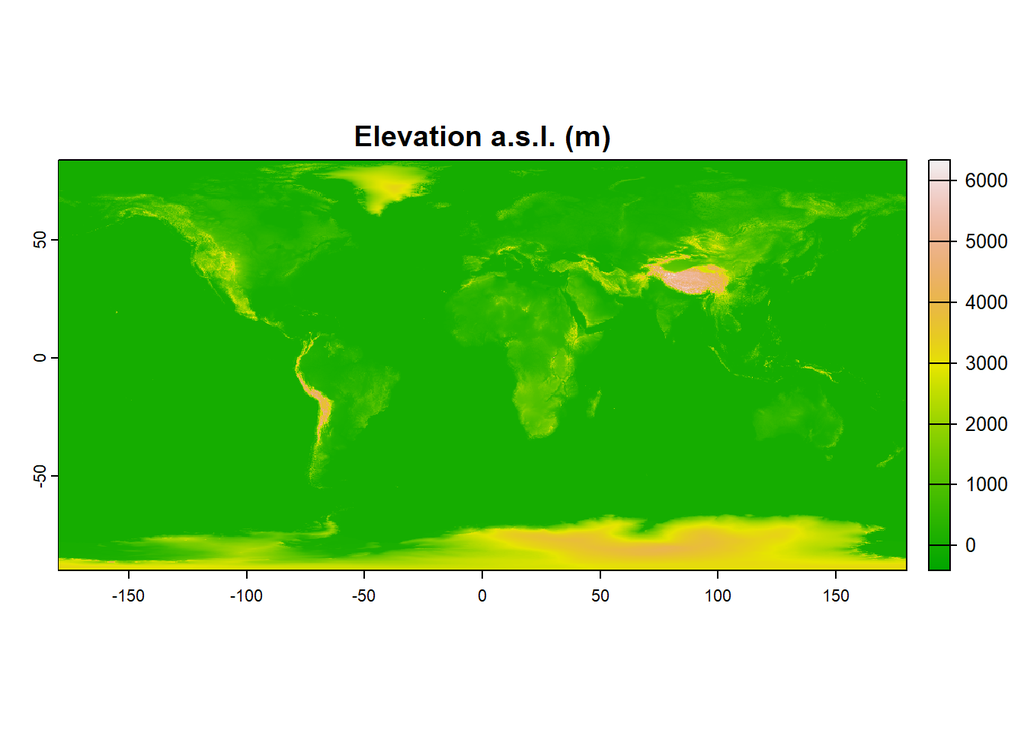

```r
plot(elev, main="Elevation a.s.l. (m)", col = terrain.colors(255))
```

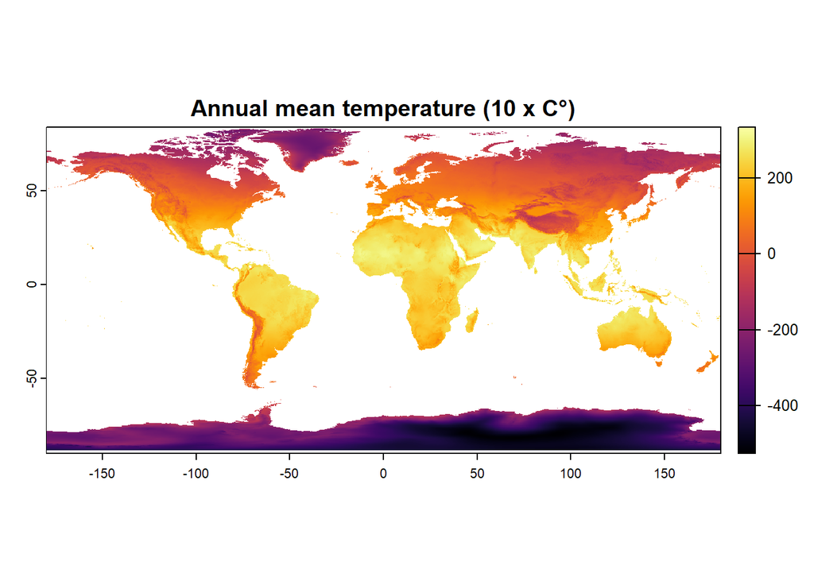

```r
# Import climate data from Chelsa at 30 arc seconds resolution -->
bio1 <- rast("data/CHELSA_bio10_01.tif") # temperature*10
bio12 <- rast("data/CHELSA_bio10_12.tif") # precipitation
plot(bio1, main="Annual mean temperature (10 x C°)", col = inferno(255))
```

**Load gridcell shapefile**

```r
# gridcells corresponding to palm distribution data and americas coastline
grid <- st_read("data/30min_grid_select50/30min_grid_select50%.shp")
americas <- st_read("data/americas/americas.shp")
```

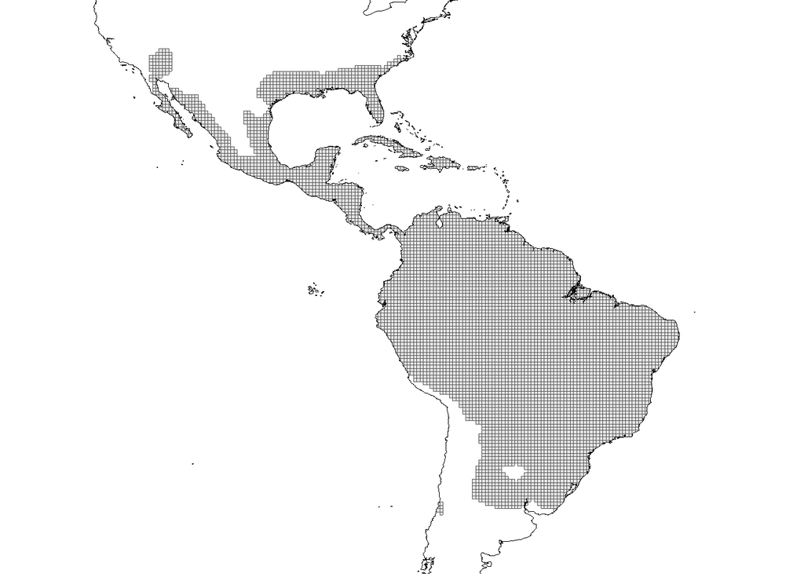

```r
# remember to define the Coordinate Reference System (CRS)
st_crs(grid) <- "+proj=longlat +ellps=WGS84 +no_defs"
st_crs(americas) <- "+proj=longlat +ellps=WGS84 +no_defs"

ggplot(grid) +
  geom_sf() +
  geom_sf(data = americas, fill = NA, color = "black") +
  theme_void() +
  ylim(-40, 40)
```

The raster layers have larger extents than they need to have for our Neotropical palm data. We can crop them based on the palm gridcell shapefile:

```r
ext(grid)
```

```
## SpatExtent : -116.000656, -35.000656, -35, 36.5 (xmin, xmax, ymin, ymax)
```

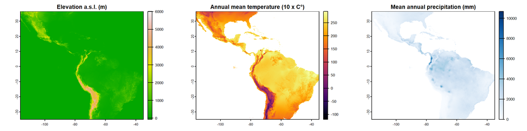

```r
elev <- crop(elev, ext(grid)) # crop raster layers to smaller extent
bio1 <- crop(bio1, ext(grid))
bio12 <- crop(bio12, ext(grid))
# elev <- elev * bio1 / bio1

par(mfrow = c(1, 3))
plot(elev, main = "Elevation a.s.l. (m)", col = terrain.colors(255))
plot(bio1, main = "Annual mean temperature (10 x C°)", col = inferno(255))
plot(bio12, main = "Mean annual precipitation (mm)",
     col = colorRampPalette(brewer.pal(9, "Blues"))(255))
```

To avoid broken numbers temperature has been multiplied by 10 in the ‘bio1’ raster layer. We can undo this by dividing by 10

```r
bio1 <- bio1/10 # Can take a little while!
```

# 2. Extracting environmental data for palm gridcells from raster layers

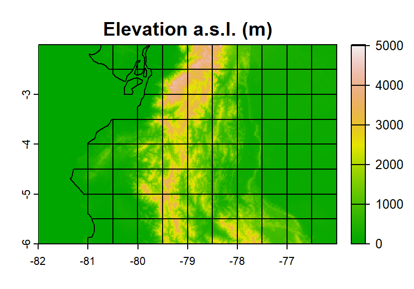

```r
zoom(elev, e = ext(c(-82, -76, -6, -2)),
     main = "Elevation a.s.l. (m)",
     col = terrain.colors(255))
plot(st_geometry(grid), add = TRUE)
```

**Extract values**

```r
bio1_values <- extract(bio1, grid[c(1:10), ])
str(bio1_values) # bio1_values is a data.frame
```

```
## 'data.frame':    36000 obs. of  2 variables:
##  $ ID             : num  1 1 1 1 1 1 1 1 1 1 ...
##  $ CHELSA_bio10_01: num  21.3 21.5 21.6 21.8 21.9 22 22 22 22.1 22.3 ...
```

```r
bio1_values$CHELSA_bio10_01[1:5] # 5 first values
```

```
## [1] 21.3 21.5 21.6 21.8 21.9
```

```r
# Mean temperature across all grid cells
mean(bio1_values$CHELSA_bio10_01)
```

```
## [1] 16.71866
```

```r
# Mean value per grid cell
tapply(bio1_values$CHELSA_bio10_01, bio1_values$ID, mean)
```

```
##        1        2        3        4        5        6        7        8
## 20.53569 15.72178 13.70375 20.61917 18.68494 16.18158 14.06617 12.29625
##        9       10
## 18.40867 16.96864
```

```r
# With dplyr
bio1_values %>%
  group_by(ID) %>%
  reframe(mean_grid = mean(CHELSA_bio10_01))
```

```
## # A tibble: 10 × 2
##       ID mean_grid
##    <dbl>     <dbl>
##  1     1      20.5
##  2     2      15.7
##  3     3      13.7
##  4     4      20.6
##  5     5      18.7
##  6     6      16.2
##  7     7      14.1
##  8     8      12.3
##  9     9      18.4
## 10    10      17.0
```

```r
# Or, we directly extract the mean temperature per grid cell
bio1_mean <- extract(bio1, grid[c(1:10), ], fun = mean)
bio1_mean
```

```
##    ID CHELSA_bio10_01
## 1   1        20.53569
## 2   2        15.72178
## 3   3        13.70375
## 4   4        20.61917
## 5   5        18.68494
## 6   6        16.18158
## 7   7        14.06617
## 8   8        12.29625
## 9   9        18.40867
## 10 10        16.96864
```

How long would it take to extract mean values for all grid cells?

```r
nrow(grid) # number of grid cells
```

```
## [1] 6038
```

```r
nrow(grid)/10*system.time(bio1_mean <- extract(bio1, grid[c(1:10), ],
                                               fun = mean))/60
```

```
##    user  system elapsed
##  0.0000  0.0000  0.6038
```

```r
# about a minute (used to be around 20 minutes with raster package)
```

Note: There are faster packages for dealing with raster layers available now (*velox*, *fasterRaster*). Here, we want to make use of a workaround that also helps us top understand the data better.

**Alternative work-around: aggregating the raster layers**  
Aggregate raster layer to the resolution of the palm grid and convert grid to spatial points

```r
bio1_30min <- aggregate(bio1, fact = 60, fun = mean, na.rm = TRUE)
dim(bio1)
```

```
## [1] 8580 9720    1
```

```r
ext(bio1)
```

```
## SpatExtent : -116.00013914485, -35.00013946885, -35.00013910885, 36.49986060515 (xmin, xmax, ymin, ymax)
```

```r
dim(bio1_30min)
```

```
## [1] 143 162   1
```

```r
ext(bio1_30min)
```

```
## SpatExtent : -116.00013914485, -35.00013946885, -35.00013910885, 36.49986060515 (xmin, xmax, ymin, ymax)
```

```r
grid_centroids <- st_centroid(grid)
```

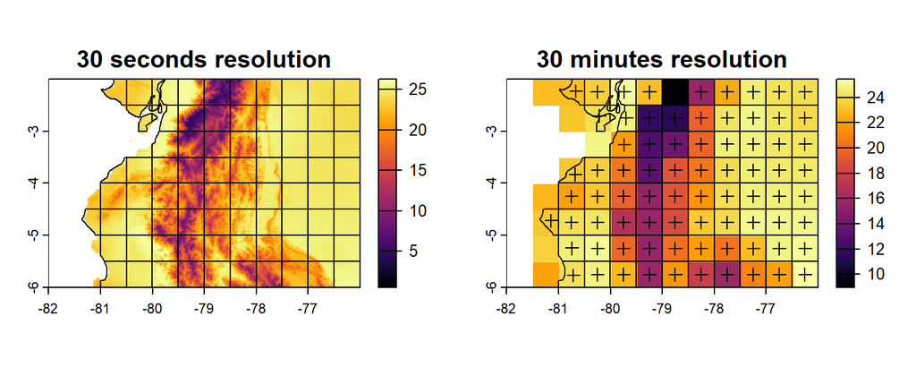

```r
par(mfrow=c(1,2))

zoom(bio1, e = ext(c(-82, -76, -6, -2)),
     main = "30 seconds resolution",
     col = inferno(255))
plot(st_geometry(grid), add=TRUE)

zoom(bio1_30min, e = ext(c(-82, -76, -6, -2)),
     main = "30 minutes resolution",
     col = inferno(255))
plot(st_geometry(grid), add=TRUE)
plot(st_geometry(grid_centroids), add = TRUE, pch = 3)
```

```r
# 30 arc-second roughly correspond to 1 km at the Equator
# 30 arc-minutes roughly correspond to 55 kms at the Equator
```

**Extract values based on spatial points and aggregated raster**

```r
# Temperature
temp_mean <- extract(bio1_30min, grid_centroids) # extract values
head(temp_mean)
```

```
##   ID CHELSA_bio10_01
## 1  1        20.53569
## 2  2        15.72178
## 3  3        13.70375
## 4  4        20.61917
## 5  5        18.68494
## 6  6        16.18158
```

```r
# Precipitation
bio12_30min <- aggregate(bio12, fact = 60, fun = mean, na.rm = TRUE)
prec_mean <- extract(bio12_30min, grid_centroids)
head(prec_mean)
```

```
##   ID CHELSA_bio10_12
## 1  1        171.7425
## 2  2        242.4058
## 3  3        281.7183
## 4  4        163.6556
## 5  5        206.7469
## 6  6        286.4769
```

```r
# Elevation range as a measure of topographic heterogeneity
elev_30min_min <- aggregate(elev, fact = 60, fun = min, na.rm = TRUE) # minimum elevation
elev_30min_max <- aggregate(elev, fact = 60, fun = max, na.rm = TRUE) # maximum elevation
elev_min <- extract(elev_30min_min, grid_centroids)
elev_max <- extract(elev_30min_max, grid_centroids)
elev_range <- elev_max$mn30_grd - elev_min$mn30_grd
elev_range[1:10]
```

```
##  [1] 1193 1671 1862 1332 1563 1552 1745  667 1517 1336
```

**Write extracted values into gridcell shapefile**

```r
grid$temp <- temp_mean$CHELSA_bio10_01
grid$prec <- prec_mean$CHELSA_bio10_12
grid$elev <- elev_range

head(grid)
```

```
## Simple feature collection with 6 features and 6 fields
## Geometry type: MULTIPOLYGON
## Dimension:     XY
## Bounding box:  xmin: -115.0007 ymin: 35.5 xmax: -113.0007 ymax: 36.5
## Geodetic CRS:  +proj=longlat +ellps=WGS84 +no_defs
##    ID AREA PORTION                       geometry     temp     prec elev
## 1 538 0.25     100 MULTIPOLYGON (((-114.0007 3... 20.53569 171.7425 1193
## 2 539 0.25     100 MULTIPOLYGON (((-113.5007 3... 15.72178 242.4058 1671
## 3 540 0.25     100 MULTIPOLYGON (((-113.0007 3... 13.70375 281.7183 1862
## 4 712 0.25     100 MULTIPOLYGON (((-114.5007 3... 20.61917 163.6556 1332
## 5 713 0.25     100 MULTIPOLYGON (((-114.0007 3... 18.68494 206.7469 1563
## 6 714 0.25     100 MULTIPOLYGON (((-113.5007 3... 16.18158 286.4769 1552
```

```r
cor(st_drop_geometry(grid[,c("temp", "prec", "elev")]))
```

```
##            temp       prec       elev
## temp  1.0000000  0.3278321 -0.5465262
## prec  0.3278321  1.0000000 -0.1371827
## elev -0.5465262 -0.1371827  1.0000000
```

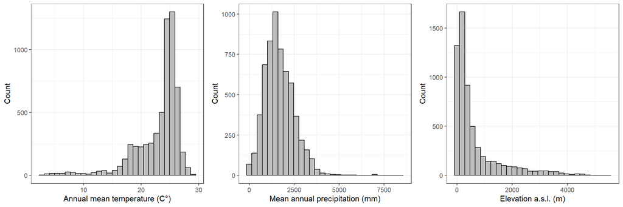

```r
plot_grid(nrow = 1, ncol = 3,
          ggplot(grid, aes(temp)) +
            geom_histogram(fill = "grey", color = "black", bins = 30) +
            labs(x = "Annual mean temperature (C°)", y = "Count") +
            theme_bw(),
          ggplot(grid, aes(prec)) +
            geom_histogram(fill = "grey", color = "black", bins = 30) +
            labs(x = "Mean annual precipitation (mm)", y = "Count") +
            theme_bw(),
          ggplot(grid, aes(elev)) +
            geom_histogram(fill = "grey", color = "black", bins = 30) +
            labs(x = "Elevation a.s.l. (m)", y = "Count") +
            theme_bw()
)
```

```r
# save(grid, file="Data/grid_env.RData")
```

# 3. Modelling palm species richness

**Join environmental data and species numbers**

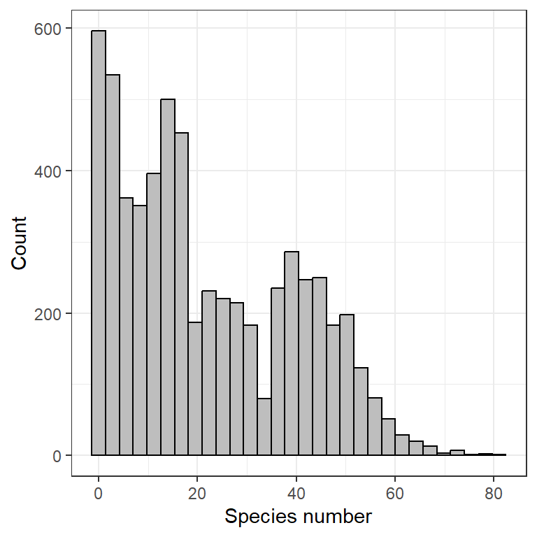

```r
load("data/grid_env.RData")
# grid <- st_as_sf(grid) # convert as a sf object
load("data/species_num.RData") # read in RData files of palm species richness from last week

ggplot(species_num, aes(spec_num)) +
  geom_histogram(fill = "grey", color = "black", bins = 30) +
  labs(x = "Species number", y = "Count") +
  theme_bw()
```

# Exercise 1

1. Join the species numbers (‘species_num’) to the grid shapefile including the newly extracted environmental data.

```
## Simple feature collection with 6 features and 9 fields
## Geometry type: MULTIPOLYGON
## Dimension:     XY
## Bounding box:  xmin: -115.0007 ymin: 35.5 xmax: -113.0007 ymax: 36.5
## Geodetic CRS:  +proj=longlat +ellps=WGS84 +no_defs
##   grid_id AREA PORTION     temp     prec elev spec_num      Long   Lat
## 1     538 0.25     100 2.053569 171.7425 1193        1 -114.2507 36.25
## 2     539 0.25     100 1.572178 242.4058 1671        1 -113.7507 36.25
## 3     540 0.25     100 1.370375 281.7183 1862        1 -113.2507 36.25
## 4     712 0.25     100 2.061917 163.6556 1332        1 -114.7507 35.75
## 5     713 0.25     100 1.868494 206.7469 1563        1 -114.2507 35.75
## 6     714 0.25     100 1.618158 286.4769 1552        1 -113.7507 35.75
##                         geometry
## 1 MULTIPOLYGON (((-114.0007 3...
## 2 MULTIPOLYGON (((-113.5007 3...
## 3 MULTIPOLYGON (((-113.0007 3...
## 4 MULTIPOLYGON (((-114.5007 3...
## 5 MULTIPOLYGON (((-114.0007 3...
## 6 MULTIPOLYGON (((-113.5007 3...
```

2. Calculate 3 linear models of species richness with each environmental variable as predictor and compare their output and AIC values.

```
##
## Call:
## lm(formula = grid$spec_num ~ grid$elev)
##
## Residuals:
##     Min      1Q  Median      3Q     Max
## -21.668 -15.351  -5.018  15.004  59.795
##
## Coefficients:
##              Estimate Std. Error t value Pr(>|t|)
## (Intercept) 2.199e+01  2.778e-01  79.138   <2e-16 ***
## grid$elev   1.543e-04  2.553e-04   0.604    0.546
## ---
## Signif. codes:  0 '***' 0.001 '**' 0.01 '*' 0.05 '.' 0.1 ' ' 1
##
## Residual standard error: 17.36 on 6036 degrees of freedom
## Multiple R-squared:  6.052e-05,  Adjusted R-squared:  -0.0001051
## F-statistic: 0.3653 on 1 and 6036 DF,  p-value: 0.5456
```

```
##
## Call:
## lm(formula = grid$spec_num ~ grid$temp)
##
## Residuals:
##     Min      1Q  Median      3Q     Max
## -24.915 -13.365  -5.048  13.506  61.804
##
## Coefficients:
##             Estimate Std. Error t value Pr(>|t|)
## (Intercept)  -9.2292     1.2476  -7.398 1.58e-13 ***
## grid$temp    13.6045     0.5341  25.473  < 2e-16 ***
## ---
## Signif. codes:  0 '***' 0.001 '**' 0.01 '*' 0.05 '.' 0.1 ' ' 1
##
## Residual standard error: 16.49 on 6036 degrees of freedom
## Multiple R-squared:  0.09706,    Adjusted R-squared:  0.09691
## F-statistic: 648.9 on 1 and 6036 DF,  p-value: < 2.2e-16
```

```
##
## Call:
## lm(formula = grid$spec_num ~ grid$prec)
##
## Residuals:
##     Min      1Q  Median      3Q     Max
## -73.889  -7.719  -1.617   6.421  46.025
##
## Coefficients:
##               Estimate Std. Error t value Pr(>|t|)
## (Intercept) -4.5925962  0.3373768  -13.61   <2e-16 ***
## grid$prec    0.0158535  0.0001802   87.98   <2e-16 ***
## ---
## Signif. codes:  0 '***' 0.001 '**' 0.01 '*' 0.05 '.' 0.1 ' ' 1
##
## Residual standard error: 11.49 on 6036 degrees of freedom
## Multiple R-squared:  0.5619, Adjusted R-squared:  0.5618
## F-statistic:  7740 on 1 and 6036 DF,  p-value: < 2.2e-16
```

```
##            df      AIC
## model_temp  3 50986.55
## model_prec  3 46620.50
## model_elev  3 51602.69
```

3. Make scatterplots for all three models and plot their regression lines

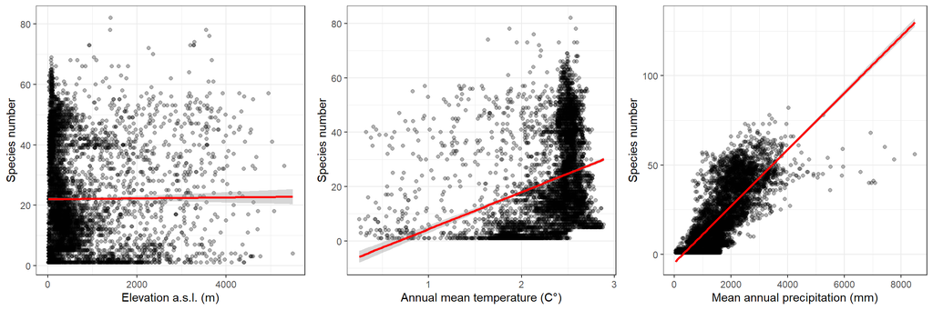

**Multipredictor model**

```r
model_full <- lm(grid$spec_num ~ grid$temp + grid$prec + grid$elev)
summary(model_full)
```

```
##
## Call:
## lm(formula = grid$spec_num ~ grid$temp + grid$prec + grid$elev)
##
## Residuals:
##     Min      1Q  Median      3Q     Max
## -76.788  -7.195  -2.092   6.115  44.902
##
## Coefficients:
##               Estimate Std. Error t value Pr(>|t|)
## (Intercept) -2.542e+01  1.063e+00  -23.91   <2e-16 ***
## grid$temp    8.399e+00  4.469e-01   18.79   <2e-16 ***
## grid$prec    1.513e-02  1.830e-04   82.68   <2e-16 ***
## grid$elev    4.186e-03  1.936e-04   21.62   <2e-16 ***
## ---
## Signif. codes:  0 '***' 0.001 '**' 0.01 '*' 0.05 '.' 0.1 ' ' 1
##
## Residual standard error: 11.01 on 6034 degrees of freedom
## Multiple R-squared:  0.5979, Adjusted R-squared:  0.5977
## F-statistic:  2990 on 3 and 6034 DF,  p-value: < 2.2e-16
```

```r
model_temp_prec <- lm(grid$spec_num ~ grid$temp + grid$prec)
model_temp_elev <- lm(grid$spec_num ~ grid$temp + grid$elev)
model_elev_prec <- lm(grid$spec_num ~ grid$prec + grid$elev)

AIC(model_full, model_temp_prec, model_temp_elev, model_elev_prec)
```

```
##                 df      AIC
## model_full       5 46106.75
## model_temp_prec  4 46555.24
## model_temp_elev  4 50678.47
## model_elev_prec  4 46448.16
```

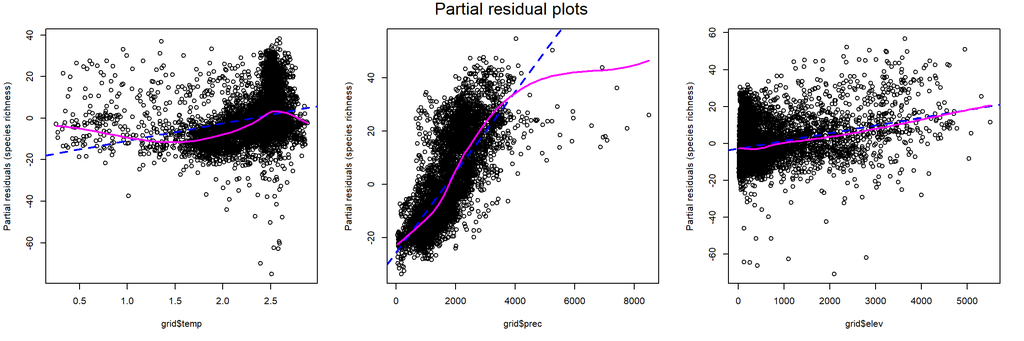

```r
crPlots(model_full, layout = c(1, 3), ask = FALSE,
        main = "Partial residual plots", grid = FALSE,
        ylab = "Partial residuals (species richness)")
```

**Plot species richness, model predictions and residuals**

Get predictions and get residuals and join them to gridcell shapefile

```r
grid$pred <- predict(model_full)
grid$resi <- residuals(model_full)
head(grid)
```

```
## Simple feature collection with 6 features and 11 fields
## Geometry type: MULTIPOLYGON
## Dimension:     XY
## Bounding box:  xmin: -115.0007 ymin: 35.5 xmax: -113.0007 ymax: 36.5
## Geodetic CRS:  +proj=longlat +ellps=WGS84 +no_defs
##   grid_id AREA PORTION     temp     prec elev spec_num      Long   Lat
## 1     538 0.25     100 2.053569 171.7425 1193        1 -114.2507 36.25
## 2     539 0.25     100 1.572178 242.4058 1671        1 -113.7507 36.25
## 3     540 0.25     100 1.370375 281.7183 1862        1 -113.2507 36.25
## 4     712 0.25     100 2.061917 163.6556 1332        1 -114.7507 35.75
## 5     713 0.25     100 1.868494 206.7469 1563        1 -114.2507 35.75
## 6     714 0.25     100 1.618158 286.4769 1552        1 -113.7507 35.75
##                         geometry        pred     resi
## 1 MULTIPOLYGON (((-114.0007 3... -0.58172640 1.581726
## 2 MULTIPOLYGON (((-113.5007 3... -1.55458225 2.554582
## 3 MULTIPOLYGON (((-113.0007 3... -1.85504836 2.855048
## 4 MULTIPOLYGON (((-114.5007 3... -0.05213129 1.052131
## 5 MULTIPOLYGON (((-114.0007 3... -0.05758508 1.057585
## 6 MULTIPOLYGON (((-113.5007 3... -0.99964553 1.999646
```

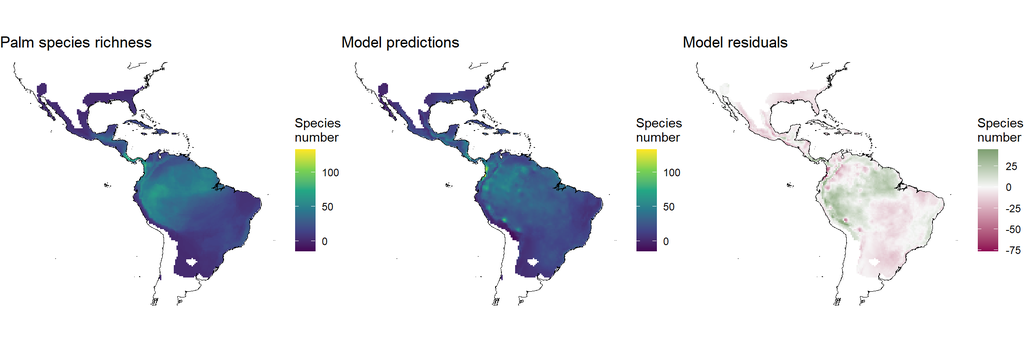

```r
# Option with discrete categories
# lmt <- ceiling(10*max(abs(range(grid$resi))))/10

plot_grid(
  nrow = 1, ncol = 3,
  ggplot(grid) +
    geom_sf(color = NA, aes(fill = spec_num)) +
    geom_sf(data = americas, fill = NA, color = "black") +
    labs(title = "Palm species richness") +
    scale_fill_viridis_c("Species\nnumber",
                         limits = range(c(grid$spec_num, grid$pred))) +
    theme_void() +
    theme(plot.title = element_text(margin = margin(0, 0, 10, 0))) +
    ylim(-40, 40),
  ggplot(grid) +
    geom_sf(color = NA, aes(fill = pred)) +
    geom_sf(data = americas, fill = NA, color = "black") +
    labs(title = "Model predictions") +
    scale_fill_viridis_c("Species\nnumber",
                         limits = range(c(grid$spec_num, grid$pred))) +
    theme_void() +
    theme(plot.title = element_text(margin = margin(0, 0, 10, 0))) +
    ylim(-40, 40),
  ggplot(grid) +
    geom_sf(color = NA, aes(fill = resi)) +
    geom_sf(data = americas, fill = NA, color = "black") +
    labs(title = "Model residuals") +
    # Option with discrete categories
    # scale_fill_stepsn("Species number", colors = brewer.pal(10, "PiYG"),
    #        n.breaks = 10, limits = c(-lmt, lmt), show.limits = TRUE) +
    scale_fill_gradient2("Species\nnumber", low = brewer.pal(11, "PiYG")[1],
                         mid = brewer.pal(11, "PiYG")[6],
                         high = brewer.pal(11, "PiYG")[11], midpoint = 0) +
    theme_void() +
    theme(plot.title = element_text(margin = margin(0, 0, 10, 0))) +
    ylim(-40, 40))
```

# Exercise 2

1. Run a model of species richness in dependence on latitude + latitude² and compare the AIC to our best model with all environmental predictors

```
##
## Call:
## lm(formula = grid$spec_num ~ abs(grid$Lat) + I(abs(grid$Lat)^2))
##
## Residuals:
##     Min      1Q  Median      3Q     Max
## -35.711  -5.179  -0.456   5.334  51.082
##
## Coefficients:
##                     Estimate Std. Error t value Pr(>|t|)
## (Intercept)        46.455629   0.360059  129.02   <2e-16 ***
## abs(grid$Lat)      -2.404688   0.054188  -44.38   <2e-16 ***
## I(abs(grid$Lat)^2)  0.031619   0.001619   19.53   <2e-16 ***
## ---
## Signif. codes:  0 '***' 0.001 '**' 0.01 '*' 0.05 '.' 0.1 ' ' 1
##
## Residual standard error: 10.83 on 6035 degrees of freedom
## Multiple R-squared:  0.6107, Adjusted R-squared:  0.6105
## F-statistic:  4733 on 2 and 6035 DF,  p-value: < 2.2e-16
```

```
##            df      AIC
## model_lat   4 45909.33
## model_full  5 46106.75
```

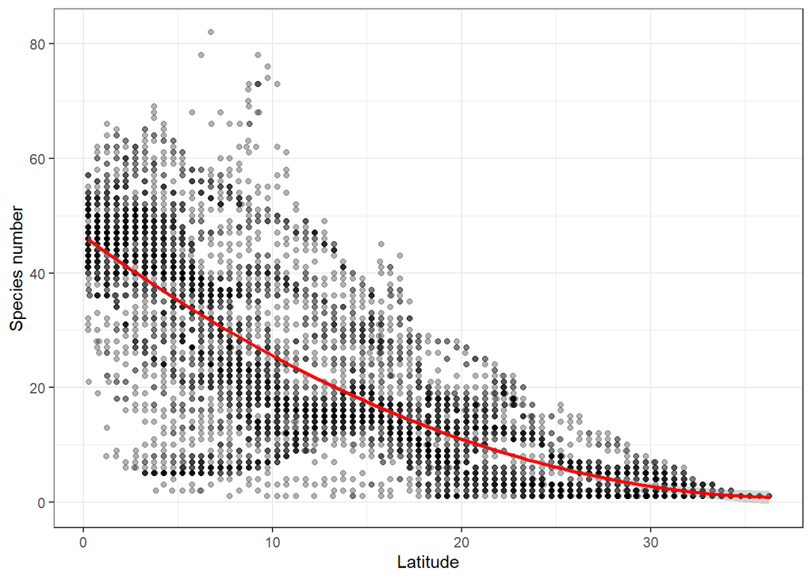